# Association analysis

### Specifying the question

Determining which products are more likely to purchased by a customer at the same time.

### Defining the metrics of success

To consider this analysis a success I should have been able to determine the rules that are most likely to occur.

### Context

My data details products that were bought by a customer at a go.

## Loading my data

```r
# loading my data
path <- "http://bit.ly/SupermarketDatasetII"


# reading the data as transactions
sup_data <- read.transactions(path, sep = ",")
sup_data
```

```
## transactions in sparse format with
##  7501 transactions (rows) and
##  119 items (columns)
```

- There are a total of 7501 transactions made and 119 items involved in those transactions.

## Checking my data

```r
# checking that sup_data is of transactions class
class(sup_data)
```

```
## [1] "transactions"
## attr(,"package")
## [1] "arules"
```

```r
# previewing the first 5 items of my data
inspect(sup_data[1:5])
```

```
##     items
## [1] {almonds,
##      antioxydant juice,
##      avocado,
##      cottage cheese,
##      energy drink,
##      frozen smoothie,
##      green grapes,
##      green tea,
##      honey,
##      low fat yogurt,
##      mineral water,
##      olive oil,
##      salad,
##      salmon,
##      shrimp,
##      spinach,
##      tomato juice,
##      vegetables mix,
##      whole weat flour,
##      yams}
## [2] {burgers,
##      eggs,
##      meatballs}
## [3] {chutney}
## [4] {avocado,
##      turkey}
## [5] {energy bar,
##      green tea,
##      milk,
##      mineral water,
##      whole wheat rice}
```

```r
# displaying the summary of my data
summary(sup_data)
```

```
## transactions as itemMatrix in sparse format with
##  7501 rows (elements/itemsets/transactions) and
##  119 columns (items) and a density of 0.03288973
##
## most frequent items:
## mineral water          eggs     spaghetti  french fries     chocolate
##          1788          1348          1306          1282          1229
##       (Other)
##         22405
##
## element (itemset/transaction) length distribution:
## sizes
##    1    2    3    4    5    6    7    8    9   10   11   12   13   14   15   16
## 1754 1358 1044  816  667  493  391  324  259  139  102   67   40   22   17    4
##   18   19   20
##    1    2    1
##
##    Min. 1st Qu.  Median    Mean 3rd Qu.    Max.
##   1.000   2.000   3.000   3.914   5.000  20.000
##
## includes extended item information - examples:
##              labels
## 1           almonds
## 2 antioxydant juice
## 3         asparagus
```

- Individuals that bought one item are the most frequent.
- The average number of items bought is around 4 items.

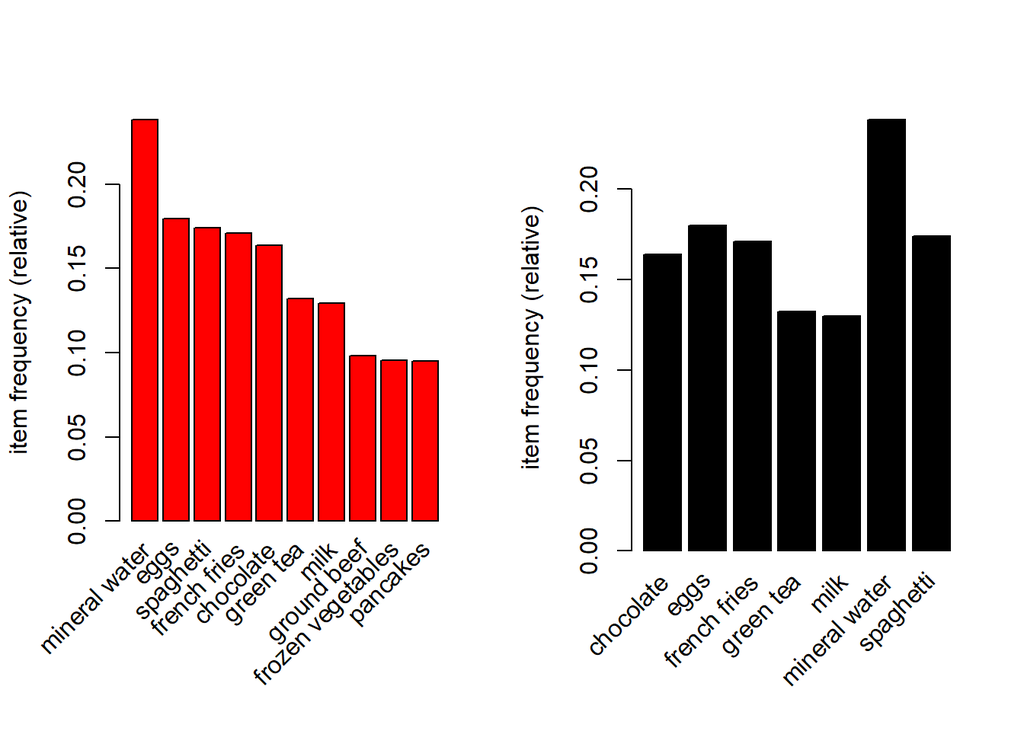

```r
# plotting the most frequent items in my data
par(mfrow= c(1,2))
itemFrequencyPlot(sup_data, topN =10, col ="red")
itemFrequencyPlot(sup_data, support =0.1, col ="black")
```

- Water was the most frequently bought item.

## Performing associative analysis

```r
# building a model based on the association rules
# a confidence of 0.8 is set and a support of 0.001

rules <- apriori(sup_data, parameter = list(supp =0.001, conf =0.8))
```

```
## Apriori
##
## Parameter specification:
##  confidence minval smax arem  aval originalSupport maxtime support minlen
##         0.8    0.1    1 none FALSE            TRUE       5   0.001      1
##  maxlen target  ext
##      10  rules TRUE
##
## Algorithmic control:
##  filter tree heap memopt load sort verbose
##     0.1 TRUE TRUE  FALSE TRUE    2    TRUE
##
## Absolute minimum support count: 7
##
## set item appearances ...[0 item(s)] done [0.00s].
## set transactions ...[119 item(s), 7501 transaction(s)] done [0.00s].
## sorting and recoding items ... [116 item(s)] done [0.00s].
## creating transaction tree ... done [0.00s].
## checking subsets of size 1 2 3 4 5 6 done [0.01s].
## writing ... [74 rule(s)] done [0.00s].
## creating S4 object  ... done [0.00s].
```

```r
rules
```

```
## set of 74 rules
```

- I have a total of 74 rules.

```r
# displaying the summary fo the rules
summary(rules)
```

```
## set of 74 rules
##
## rule length distribution (lhs + rhs):sizes
##  3  4  5  6
## 15 42 16  1
##
##    Min. 1st Qu.  Median    Mean 3rd Qu.    Max.
##   3.000   4.000   4.000   4.041   4.000   6.000
##
## summary of quality measures:
##     support           confidence        coverage             lift
##  Min.   :0.001067   Min.   :0.8000   Min.   :0.001067   Min.   : 3.356
##  1st Qu.:0.001067   1st Qu.:0.8000   1st Qu.:0.001333   1st Qu.: 3.432
##  Median :0.001133   Median :0.8333   Median :0.001333   Median : 3.795
##  Mean   :0.001256   Mean   :0.8504   Mean   :0.001479   Mean   : 4.823
##  3rd Qu.:0.001333   3rd Qu.:0.8889   3rd Qu.:0.001600   3rd Qu.: 4.877
##  Max.   :0.002533   Max.   :1.0000   Max.   :0.002666   Max.   :12.722
##      count
##  Min.   : 8.000
##  1st Qu.: 8.000
##  Median : 8.500
##  Mean   : 9.419
##  3rd Qu.:10.000
##  Max.   :19.000
##
## mining info:
##      data ntransactions support confidence
##  sup_data          7501   0.001        0.8
```

- The average number of items to occur in a rule is around 4 and the maximum is six items.
- The average confidence for the rules is 85.04 which is a really good value.
- The lift values have a minimum value of 3 which is a good indication as to how the items in the set are highly dependant on each other.

```r
# ordering the rules to obtain the ones with the highest likelihood
# the order will occur according to the value of confidence

sorted_rules <- sort(rules, by ="confidence", decreasing = TRUE)
inspect(sorted_rules[1:5])
```

```
##     lhs                                          rhs             support
## [1] {french fries,mushroom cream sauce,pasta} => {escalope}      0.001066524
## [2] {ground beef,light cream,olive oil}       => {mineral water} 0.001199840
## [3] {cake,meatballs,mineral water}            => {milk}          0.001066524
## [4] {cake,olive oil,shrimp}                   => {mineral water} 0.001199840
## [5] {mushroom cream sauce,pasta}              => {escalope}      0.002532996
##     confidence coverage    lift      count
## [1] 1.00       0.001066524 12.606723  8
## [2] 1.00       0.001199840  4.195190  9
## [3] 1.00       0.001066524  7.717078  8
## [4] 1.00       0.001199840  4.195190  9
## [5] 0.95       0.002666311 11.976387 19
```

- The first four rules have a confidence of 100% and the fifth 95% confidence.
- The first rule indicates that an individual purchasing french fries, mushroom cream sauce and pasta is 100% likely to purchase escalope as well.
- The second rule indicates that for individuals that have purchased ground beef, light cream and olive oil, there is a 100% confidence that they have bought mineral water as well.
- The third rule expresses that individuals that bought cake, meatballs and mineral water are 100% likely to have made a purchase of milk as well.
- The fourth rule indicates that individuals that have made a purchase of cake, olive oil and shrimp can be said- with a 100% confidence - to have made a purchase of water as well.
- The fifth rule is almost similar to the first except french fries is not included in the antecedent. The rule indicates that an individual that has bought mushroom cream sauce and pasta is 95% likely to have made a purchase of escalope as well.